# Day 4: Linear and Multiple Regression

## 0. Overview

In this practical example, we will use two factors (i) **number of factors** (`Lv`) and (ii) **factor dissimilarity** (`dissim`) to predict soil decomposition rate (`Decom`), with the dataset `MultiFactor_data.csv`.

#### Goal

- Explain what linear regressions estimate
- Fit simple linear regression and extend to multiple regression
- Compare models (ANOVA, AIC/BIC, ΔR²) and report results clearly

#### What we use from the data

- `Decom`: Soil decomposition rate (response variable).
- `Lv`: factor level: number of factors acting simultaneously (numerical predictor).
- `dissim`: factor dissimilarity, an index measures how dissimilar the co-acting factors are (continuous predictor)

```r
##Import dataset
# Read the combined dataset (ensure the CSV file is in your working directory)
dat <- read.csv("MultiFactor_data.csv")
```

#### Install and load packages

```r
library(dplyr)
library(ggplot2)
library(tidyverse)
library(broom)
library(car)
library(lmtest)
```

## 1. Subsetting data for regression analysis

```r
# Keep only variables used in regression analysis and drop missing values
dat2 <- dat %>%
  dplyr::select(Decom, Lv, dissim) %>%
  drop_na()

nrow(dat2)
```

```
## [1] 343
```

```r
summary(dat2)
```

```
##      Decom              Lv            dissim
##  Min.   :0.4242   Min.   :0.000   Min.   :0.0000
##  1st Qu.:0.6342   1st Qu.:1.000   1st Qu.:0.0000
##  Median :0.6570   Median :1.000   Median :0.0000
##  Mean   :0.6507   Mean   :2.603   Mean   :0.2165
##  3rd Qu.:0.6769   3rd Qu.:5.000   3rd Qu.:0.4515
##  Max.   :0.7735   Max.   :8.000   Max.   :1.0000
```

## 2. Understand data patterns

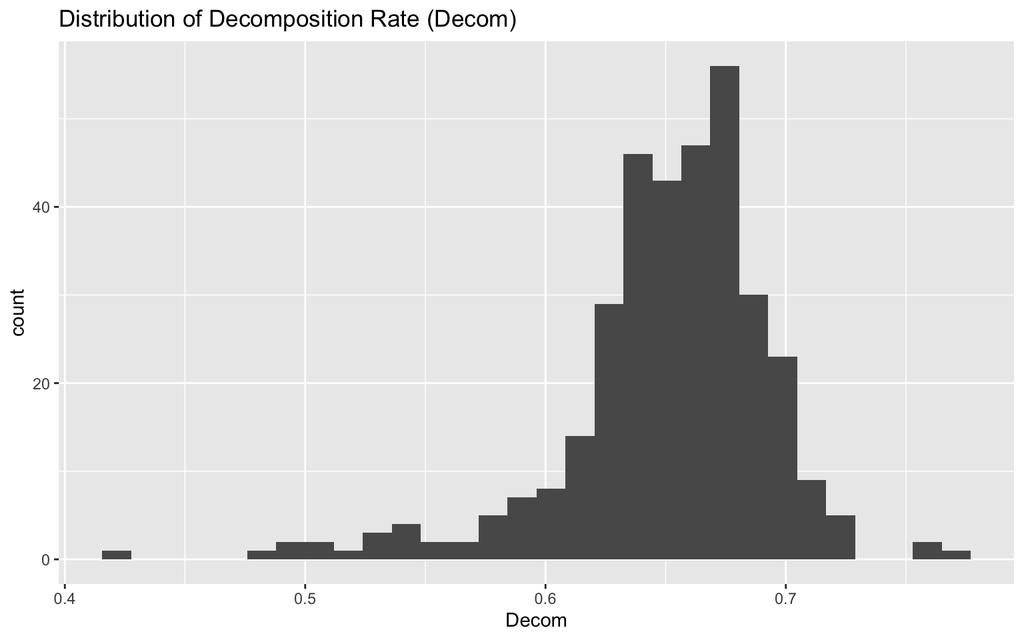

```r
# Distribution of Decom
ggplot(dat2, aes(Decom)) +
  geom_histogram(bins = 30) +
  labs(title = "Distribution of Decomposition Rate (Decom)")
```

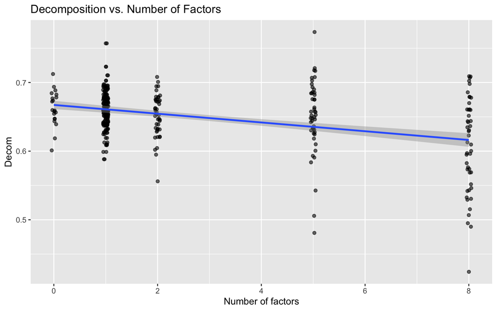

```r
# Scatter with linear smoother: Decom ~ n_factors
ggplot(dat2, aes(Lv, Decom)) +
  geom_point(alpha = 0.6, position = position_jitter(width = 0.05, height = 0)) +
  geom_smooth(method = "lm", se = TRUE) +
  labs(x = "Number of factors", y = "Decom",
       title = "Decomposition vs. Number of Factors")
```

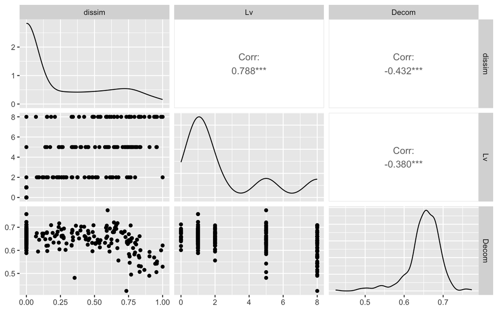

```r
# Optional: pairs plot to see relationships & correlations
GGally::ggpairs(dat2, columns = c("dissim","Lv","Decom"))
```

## 3. Build simple linear model

#### Model formular:

`Decom ~ Lv` Predict soil decomposition rate from factor number `lv`.

```r
m1 <- lm(Decom ~ Lv, data = dat2)

summary(m1)     # Coefs, p-values, R²
```

```
##
## Call:
## lm(formula = Decom ~ Lv, data = dat2)
##
## Residuals:
##       Min        1Q    Median        3Q       Max
## -0.192035 -0.021474 -0.000894  0.021596  0.138152
##
## Coefficients:
##               Estimate Std. Error t value Pr(>|t|)
## (Intercept)  0.6673085  0.0030802 216.644  < 2e-16 ***
## Lv          -0.0063842  0.0008416  -7.586 3.17e-13 ***
## ---
## Signif. codes:  0 '***' 0.001 '**' 0.01 '*' 0.05 '.' 0.1 ' ' 1
##
## Residual standard error: 0.0401 on 341 degrees of freedom
## Multiple R-squared:  0.1444, Adjusted R-squared:  0.1419
## F-statistic: 57.55 on 1 and 341 DF,  p-value: 3.168e-13
```

```r
broom::glance(m1)[c("r.squared","adj.r.squared","AIC","BIC")]
```

```
## # A tibble: 1 × 4
##   r.squared adj.r.squared    AIC    BIC
##       <dbl>         <dbl>  <dbl>  <dbl>
## 1     0.144         0.142 -1229. -1218.
```

#### Interpret model results

- **estimate**: For every 1-unit increase in `Lv`, how much `Decom` increases on average. The sign of estimate indicates **positive** or **nagative** correlation between independent and dependent variables.
- **Model fit**: `r.squared` tells you the proportion of variance in `Decom` explained by `Lv`. `adj.r.squared` is slightly penalized version of R² — more useful for comparing models with different numbers of predictors.

## 4. Multiple regression (add factor dissimilarity index)

#### Model formular:

`Decom ~ Lv + dissim` Predict soil decomposition rate with two predictors `lv` and `dissim`.

```r
m2 <- lm(Decom ~ Lv + dissim, data = dat2) # build multiple regression model from two predictors

summary(m2)
```

```
##
## Call:
## lm(formula = Decom ~ Lv + dissim, data = dat2)
##
## Residuals:
##       Min        1Q    Median        3Q       Max
## -0.191693 -0.022074  0.000972  0.019407  0.145637
##
## Coefficients:
##              Estimate Std. Error t value Pr(>|t|)
## (Intercept)  0.665849   0.003018 220.598  < 2e-16 ***
## Lv          -0.001760   0.001331  -1.322    0.187
## dissim      -0.048874   0.011086  -4.408  1.4e-05 ***
## ---
## Signif. codes:  0 '***' 0.001 '**' 0.01 '*' 0.05 '.' 0.1 ' ' 1
##
## Residual standard error: 0.03905 on 340 degrees of freedom
## Multiple R-squared:  0.1907, Adjusted R-squared:  0.1859
## F-statistic: 40.05 on 2 and 340 DF,  p-value: 2.412e-16
```

```r
broom::glance(m2)[c("r.squared","adj.r.squared","AIC","BIC")]
```

```
## # A tibble: 1 × 4
##   r.squared adj.r.squared    AIC    BIC
##       <dbl>         <dbl>  <dbl>  <dbl>
## 1     0.191         0.186 -1246. -1231.
```

#### Compare `m1` vs `m2`

Does adding another predictor `dissim` improve explanatory power beyond `Lv`?

```r
# Anova test comparing two models
anova(m1, m2)   # nested F-test: significant p => m2 improves fit
```

```
## Analysis of Variance Table
##
## Model 1: Decom ~ Lv
## Model 2: Decom ~ Lv + dissim
##   Res.Df     RSS Df Sum of Sq      F    Pr(>F)
## 1    341 0.54823
## 2    340 0.51859  1  0.029643 19.434 1.398e-05 ***
## ---
## Signif. codes:  0 '***' 0.001 '**' 0.01 '*' 0.05 '.' 0.1 ' ' 1
```

```r
# Comparing model AIC (Akaike Information Criterion)
delta_AIC <- broom::glance(m2)["AIC"] - broom::glance(m1)["AIC"]

# Increased r2 of model_2 compared to model_1
delta_r2 <- glance(m2)$r.squared - glance(m1)$r.squared
delta_r2
```

```
## [1] 0.04626221
```

#### Interpret model comparison

- **ANOVA testing**: If additional predictors in the more complex model explain a significant amount of extra variance in the outcome variable.
- **Comparing model AIC**: AIC measures the trade-off between model fit and model complexity. The lower AIC, the better the model (better balance of fit and simplicity). The absolute AIC value doesn’t matter — only differences between models do. To compare AIC values, compute them for each model and pick the one with the lower AIC. If the difference (ΔAIC) is > 2, the lower-AIC model is meaningfully better.
- **delta_r2**: How much r2 has been improved when adding another predictor.